# Module 3. Statistical foundations and traditional approaches

Slides

**Simulated data**

All examples use simulated data from fictional studies. Results illustrate methods; they are not empirical findings.

## Traditional methods are still everywhere, so we need to judge them

- Regression ignoring correlation, paired t-tests, repeated-measures ANOVA, ANCOVA at the last visit, a test at every visit
- Each answers a narrow question under strong assumptions
- Goal: know what each one estimates, when it is adequate, and why Module 4 moves on

## Learning outcomes

- **3.1** Interpret coefficients, interactions, CIs and residuals in models with time
- **3.2** Carry out a paired comparison and an RM-ANOVA; state assumptions
- **3.3** Explain sphericity, apply GG and HF corrections, list RM-ANOVA limitations
- **3.4** Compare follow-up-only, change-score and ANCOVA analyses
- **3.5** Explain why separate tests at each visit are inefficient and inflate comparisons

## WALK: three arms, six scheduled visits, incomplete data

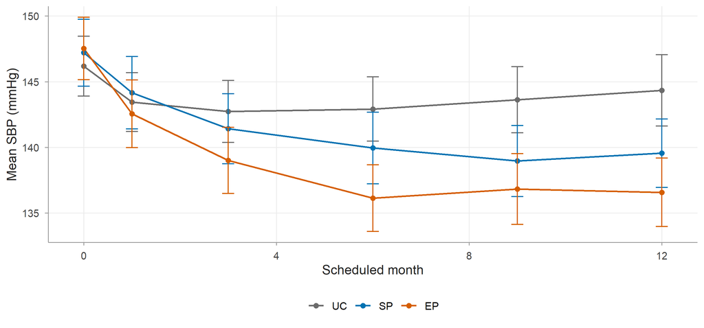

Only 238 of 360 participants have all six visits; 288 have month 12.

# Part 1. Regression foundations

## The arm-by-time interaction carries the treatment effect

$$y_{ij} = \beta_0 + \beta_1 t_{ij} + \beta_2 \text{SP}_i + \beta_3 \text{EP}_i + \beta_4 t_{ij}\text{SP}_i + \beta_5 t_{ij}\text{EP}_i + \varepsilon_{ij}$$

- $\beta_2, \beta_3$: arm differences **at month 0**
- $\beta_4, \beta_5$: differences in **slope** (mmHg/month) from UC
- $\varepsilon_{ij} \sim N(0, \sigma^2)$, assumed **independent**

## Fitting it with `lm()`

```r
m_ols <- lm(sbp ~ month * arm, data = walk)
summary(m_ols)
```

| term | estimate | se | lower | upper |
| --- | --- | --- | --- | --- |
| (Intercept) | 144.33 | 0.80 | 142.76 | 145.90 |
| month | -0.08 | 0.12 | -0.33 | 0.16 |
| armSP | 0.64 | 1.13 | -1.58 | 2.87 |
| armEP | -0.37 | 1.13 | -2.59 | 1.85 |
| month:armSP | -0.51 | 0.17 | -0.85 | -0.17 |
| month:armEP | -0.72 | 0.18 | -1.07 | -0.38 |

## Residuals from the same participant are strongly correlated

|  | 0 | 1 | 3 | 6 | 9 | 12 |
| --- | --- | --- | --- | --- | --- | --- |
| 0 | 1.00 | 0.87 | 0.79 | 0.73 | 0.75 | 0.72 |
| 1 | 0.87 | 1.00 | 0.83 | 0.79 | 0.76 | 0.74 |
| 3 | 0.79 | 0.83 | 1.00 | 0.78 | 0.75 | 0.74 |
| 6 | 0.73 | 0.79 | 0.78 | 1.00 | 0.78 | 0.75 |
| 9 | 0.75 | 0.76 | 0.75 | 0.78 | 1.00 | 0.83 |
| 12 | 0.72 | 0.74 | 0.74 | 0.75 | 0.83 | 1.00 |

Independence would need these to be near 0. They range from 0.72 to 0.87.

## Try it

Workbook exercise 1: fit the arm-by-time regression, interpret every coefficient, and inspect the residual correlations (LO 3.1).

# Part 2. The paired t-test

## A paired t-test answers a within-group question

$$d_i = y_{i,12} - y_{i,0}, \qquad t = \frac{\bar d}{s_d/\sqrt n}, \qquad \operatorname{Var}(d_i) = \sigma_0^2 + \sigma_{12}^2 - 2\rho\sigma_0\sigma_{12}$$

- Pairing removes stable between-person differences
- High correlation $\rho$ makes the differences much less variable
- The estimand is the mean change **within one arm**

## EP falls by 10.2 mmHg, but UC also changes

```r
ep <- wide |> filter(arm == "EP", !is.na(sbp_m0), !is.na(sbp_m12))
t.test(ep$sbp_m12, ep$sbp_m0, paired = TRUE)
```

| Arm | n pairs | Mean change (95% CI) |
| --- | --- | --- |
| EP | 93 | -10.2 (-12.1 to -8.3) |
| UC | 95 | -1.0 (-3.1 to 1.1) |

## Try it

Workbook exercise 2: paired t-tests in each arm and why they do not compare arms (LO 3.2).

# Part 3. Repeated-measures ANOVA

## RM-ANOVA is a random-intercept model with categorical time and complete data

$$y_{ij} = \mu + \alpha_g + \gamma_j + (\alpha\gamma)_{gj} + b_{0i} + \varepsilon_{ij}, \quad b_{0i} \sim N(0,\tau_0^2), \ \varepsilon_{ij} \sim N(0,\sigma^2)$$

- Between-subject test: arm (averaged over visits)
- Within-subject tests: visit, **arm-by-visit** (the question in a trial)
- Implies equal variances and equal correlations (compound symmetry)

## Two routes in base R

```r
cc <- wide[complete.cases(wide[, yv]), ]            # listwise deletion
rm_aov <- aov(sbp ~ arm * visit + Error(id / visit), data = lc)   # long

Y <- as.matrix(cc[, yv])                             # wide
rm_mlm <- lm(Y ~ arm, data = cc)
idata <- data.frame(visit = factor(yv, levels = yv))
anova(rm_mlm, X = ~1, idata = idata, test = "Spherical")
mauchly.test(rm_mlm, X = ~1, idata = idata)
```

## The arms follow different patterns over time

| Effect | F | df | p |
| --- | --- | --- | --- |
| Arm (between) | 1.70 | 2, 235 | p = 0.186 |
| Visit | 36.97 | 5, 1175 | p < 0.001 |
| Arm × visit | 7.48 | 10, 1175 | p < 0.001 |

238 completers. Mauchly W = 0.65, p < 0.001.

## Sphericity: every pairwise difference should be equally variable

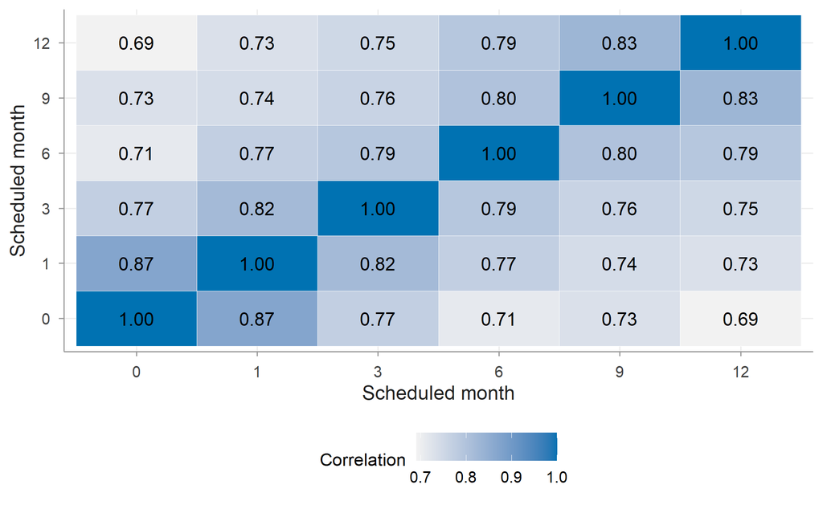

## The variance of differences is far from constant

| pair | var_diff |
| --- | --- |
| m0 vs m1 | 41.6 |
| m1 vs m3 | 58.5 |
| m9 vs m12 | 58.5 |
| m1 vs m12 | 93.1 |
| m0 vs m6 | 100.4 |
| m0 vs m12 | 104.2 |

Smallest 41.6, largest 104.2 mmHg². Under sphericity all 15 would be similar.

## Greenhouse–Geisser and Huynh–Feldt shrink the degrees of freedom

$$\hat\epsilon_{\text{GG}} = \frac{(\sum_r \lambda_r)^2}{(k-1)\sum_r \lambda_r^2}, \qquad \lambda_r \text{ eigenvalues of } C^\top S C$$

- WALK: $\hat\epsilon_{\text{GG}}$ = 0.85, $\hat\epsilon_{\text{HF}}$ = 0.87
- Interaction df become 8.5 and 998 (GG); corrected p < 0.001
- GG is conservative near 1; HF less so (Greenhouse and Geisser 1959; Huynh and Feldt 1976)

## RM-ANOVA has limitations that corrections cannot fix

- **Complete cases only**: 122 of 360 participants (34%) dropped
- **Fixed occasions**: actual visit times are discarded
- **No time-varying covariates** (e.g. steps)
- **No individual slopes**: only a shift in level per person
- **Omnibus F-tests**, not an effect estimate with CI

## Try it

Workbook exercise 3: RM-ANOVA on completers, Mauchly’s test and the corrected p-values (LO 3.2, 3.3).

# Part 4. Baseline and one follow-up

## Three analyses of month 12 estimate the same effect in a trial

$$\begin{aligned}
\text{Follow-up:}\ & y_{i,12} = \beta_0 + \beta_1\text{SP}_i + \beta_2\text{EP}_i + \varepsilon_i \\
\text{Change:}\ & y_{i,12} - y_{i0} = \beta_0 + \beta_1\text{SP}_i + \beta_2\text{EP}_i + \varepsilon_i \\
\text{ANCOVA:}\ & y_{i,12} = \beta_0 + \beta_1\text{SP}_i + \beta_2\text{EP}_i + \gamma y_{i0} + \varepsilon_i
\end{aligned}$$

Follow-up fixes $\gamma = 0$, change fixes $\gamma = 1$, ANCOVA estimates $\gamma$.

## Precision depends on the baseline–follow-up correlation $\rho$

$$\operatorname{Var} \propto \quad 1 \ (\text{follow-up}), \qquad 2(1-\rho) \ (\text{change}), \qquad 1-\rho^2 \ (\text{ANCOVA})$$

- Change beats follow-up only if $\rho > 0.5$
- ANCOVA is never worse than either (Senn 2006; Vickers and Altman 2001)
- WALK: $\rho$ = 0.69

## In WALK, ANCOVA gives the narrowest intervals

```r
m_anc <- lm(sbp_m12 ~ arm + sbp_m0, data = d12)
```

| Analysis | SP vs UC | EP vs UC | SE (EP) |
| --- | --- | --- | --- |
| Follow-up only | -4.8 (-8.4 to -1.1) | -7.8 (-11.5 to -4.0) | 1.90 |
| Change score | -5.7 (-8.4 to -3.0) | -9.2 (-11.9 to -6.4) | 1.41 |
| ANCOVA | -5.5 (-8.0 to -2.9) | -8.8 (-11.4 to -6.2) | 1.33 |

288 participants with month 12. Truth (simulation only): −4.6 and −8.1.

## Simulation: ANCOVA is most precise at every correlation

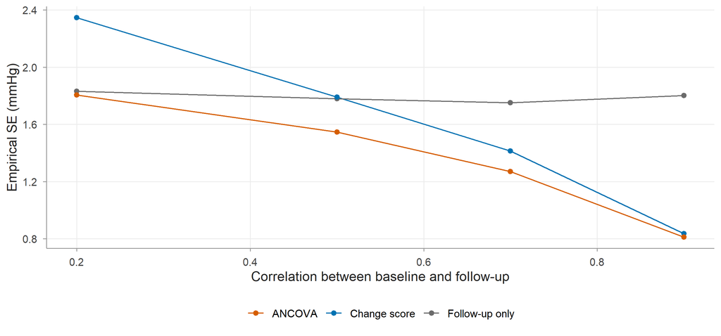

## Lord’s paradox: without randomisation, change and ANCOVA disagree

- Two pre-existing groups, true levels 135 vs 150, **no change** in either
- Change score: B − A = -0.83 mmHg (p = 0.191)
- ANCOVA: B − A = 4.81 mmHg (p < 0.001)
- Different questions; they coincide only when groups are comparable at baseline (randomisation)

## Try it

Workbook exercises 4 and 5: the three month-12 analyses and checking ANCOVA assumptions (LO 3.4).

# Part 5. Separate tests at each visit

## A test at every visit multiplies false positives and wastes information

- 6 visits × 2 comparisons = 12 tests: $1 - 0.95^{12}$ = 0.46 if independent
- Each test ignores baseline: SE of follow-up-only analysis
- Each visit analyses different people as dropout accumulates

Participants analysed at each scheduled month

| 0 | 1 | 3 | 6 | 9 | 12 |
| --- | --- | --- | --- | --- | --- |
| 360 | 324 | 319 | 309 | 297 | 288 |

## Visit-wise estimates look informative but mix effect and selection

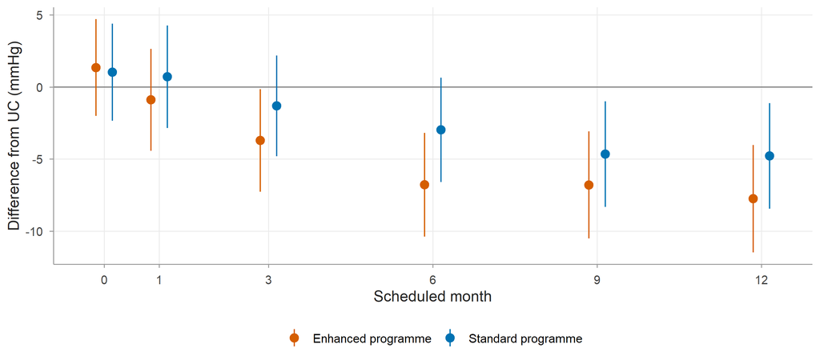

## Try it

Independent exercise: compare the per-visit tests with ANCOVA at month 6 (LO 3.5).

# Part 6. Putting it together

## Each traditional method has a narrow use

| Method | Use it for | Main problem |
| --- | --- | --- |
| OLS on long data | Understanding the mean model | Invalid SEs |
| Paired t-test | Within-arm change | Not a comparison of arms |
| RM-ANOVA | Complete, balanced, fixed visits | Listwise deletion, sphericity, no estimates |
| ANCOVA at one visit | Single follow-up in a trial | Ignores other visits; complete cases |
| Test per visit | Nothing as a primary analysis | Multiplicity, inefficiency, shifting samples |

## The linear mixed model keeps what is good and removes the restrictions

- Uses all 360 participants and all 1897 observations
- Uses actual visit times, allows random slopes
- Valid under MAR dropout (if correctly specified)
- Gives the difference in mean change at month 12 with a CI

## Summary

- Interactions carry the treatment effect on change; main effects are at time 0
- Paired tests describe change within a group
- RM-ANOVA needs sphericity and complete data; correct with GG/HF
- In a randomised trial with one follow-up, prefer ANCOVA
- Never use a test at every visit as the primary analysis

## References

Greenhouse, Samuel W., and Seymour Geisser. 1959. ‘On Methods in the Analysis of Profile Data’. *Psychometrika* 24 (2): 95–112. https://doi.org/10.1007/BF02289823.

Huynh, Huynh, and Leonard S. Feldt. 1976. ‘Estimation of the Box Correction for Degrees of Freedom from Sample Data in Randomized Block and Split-Plot Designs’. *Journal of Educational Statistics* 1 (1): 69–82. https://doi.org/10.3102/10769986001001069.

Senn, Stephen. 2006. ‘Change from Baseline and Analysis of Covariance Revisited’. *Statistics in Medicine* 25 (24): 4334–44. https://doi.org/10.1002/sim.2682.

Twisk, Jos, Lisa Bosman, Trynke Hoekstra, Judith Rijnhart, Marieke Welten, and Martijn Heymans. 2018. ‘Different Ways to Estimate Treatment Effects in Randomised Controlled Trials’. *Contemporary Clinical Trials Communications* 10: 80–85. https://doi.org/10.1016/j.conctc.2018.03.008.

Vickers, Andrew J., and Douglas G. Altman. 2001. ‘Analysing Controlled Trials with Baseline and Follow up Measurements’. *BMJ* 323 (7321): 1123–24. https://doi.org/10.1136/bmj.323.7321.1123.